# Max Report Draft

MaxwellPohlman

2024-12-01

```r
library(tidyverse)
library(tidymodels)
library(janitor)
library(broom)
library(patchwork)
```

```r
details = read_rds('../data/clean_data/details_clean.rds')
fatalities = read_rds('../data/clean_data/fatalities_clean.rds')
```

# Event Type Averages and Data Limitations

We split event types into two categories: more or less damaging/deadly (compared to the global average). This assessed whether increased fatalities and damages over time were reflected equally in both severe and less severe storms.

The below chunk shows the steps of this categorisation process:

```r
# Rename redundant event type names
  details <- details %>%
    mutate(event_type = replace(event_type, event_type == "Hurricane (Typhoon)", "Hurricane"))

# Select relevant columns and replace NA values
details_selected <- details %>%
  select(event_type, deaths_direct, deaths_indirect, damage_total, begin_dt) %>%
  mutate(
    year = as.numeric(format(as.Date(begin_dt, format = "%Y-%m-%d"), "%Y"))
  ) %>%
  na.omit()

# Calculate total fatalities and damage per event, and group by event type
details_grouped <- details_selected %>%
  mutate(
    fatalities_total = deaths_direct + deaths_indirect
  ) %>%
  group_by(event_type) %>%
  summarise(
    avg_fatalities_by_type = mean(fatalities_total, na.rm = TRUE),
    avg_damage_by_type = mean(damage_total, na.rm = TRUE)
  ) %>%
  ungroup()

# Calculate global averages and assign groups
global_averages <- details_grouped %>%
  summarise(
    global_avg_fatalities = mean(avg_fatalities_by_type, na.rm = TRUE),
    global_avg_damage = mean(avg_damage_by_type, na.rm = TRUE)
  )

# Add grouping for more/less deadly and damaging based on global averages
details_grouped <- details_grouped %>%
  mutate(
    fatality_group = if_else(avg_fatalities_by_type > global_averages$global_avg_fatalities,
                             "More Deadly", "Less Deadly"),
    damage_group = if_else(avg_damage_by_type > global_averages$global_avg_damage,
                           "More Damaging", "Less Damaging")
  )
```

We used average impact instead of net impact to determine whether total fatalities and damages increased due to stronger storms or simply greater storm frequency.

We first calculated averages for the entire dataset (1996–2023):

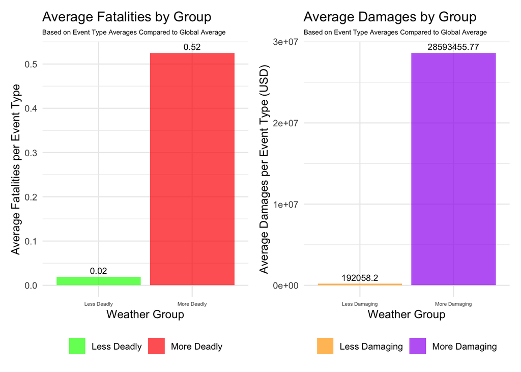

```r
# Adjusted Graph for Fatalities (All Data)
fatality_graph <- details_grouped %>%
  ggplot(aes(x = fatality_group,
             y = avg_fatalities_by_type,
             fill = fatality_group)) +
  stat_summary(fun = "mean", geom = "bar", position = "dodge", alpha = 0.7) +
    geom_text(stat = "summary", fun = "mean", aes(label = round(after_stat(y), 2)),
            vjust = -0.5, size = 3) +
  scale_fill_manual(values = c("More Deadly" = "red", "Less Deadly" = "green")) +
  labs(
    title = "Average Fatalities by Group",
    subtitle = "Based on Event Type Averages Compared to Global Average",
    x = "Weather Group",
    y = "Average Fatalities per Event Type",
    fill = NULL
  ) +
  theme_minimal() +
  theme(
    legend.position = "bottom",
    plot.subtitle = element_text(size = 6.5),
    axis.text.x = element_text(size = 5)
  )

# Adjusted Graph for Damages (All Data)
damage_graph <- details_grouped %>%
  ggplot(aes(x = damage_group,
             y = avg_damage_by_type,
             fill = damage_group)) +
  stat_summary(fun = "mean", geom = "bar", position = "dodge", alpha = 0.7) +
    geom_text(stat = "summary", fun = "mean", aes(label = round(after_stat(y), 2)),
            vjust = -0.5, size = 3) +
  scale_fill_manual(values = c("More Damaging" = "purple", "Less Damaging" = "orange")) +
  labs(
    title = "Average Damages by Group",
    subtitle = "Based on Event Type Averages Compared to Global Average",
    x = "Weather Group",
    y = "Average Damages per Event Type (USD)",
    fill = NULL
  ) +
  theme_minimal() +
  theme(
    legend.position = "bottom",
    plot.subtitle = element_text(size = 6.5),
    axis.text.x = element_text(size = 5)
  )

# Combine  plots
combined_original <- fatality_graph + damage_graph

# Display plots
combined_original
```

This was repeated for 1996–7 and 2022–3, using two-year periods to minimize outliers. Coding these graphs involved filtering for year, recalculating averages, and regrouping event types. A sample of this is shown below:

```r
# Filter for 1996
details_1996_7 <- details_selected %>% filter(year %in% c(1996, 1997))
details_grouped_1996_7 <- details_1996_7 %>%
  mutate(fatalities_total = deaths_direct + deaths_indirect) %>%
  group_by(event_type) %>%
  summarise(
    avg_fatalities_by_type = mean(fatalities_total, na.rm = TRUE),
    avg_damage_by_type = mean(damage_total, na.rm = TRUE)
  ) %>%
  ungroup()

# Recalculate global averages for 1996 data
global_averages_1996_7 <- details_grouped_1996_7 %>%
  summarise(
    global_avg_fatalities = mean(avg_fatalities_by_type, na.rm = TRUE),
    global_avg_damage = mean(avg_damage_by_type, na.rm = TRUE)
  )

# Add grouping for 1996 data
details_grouped_1996_7 <- details_grouped_1996_7 %>%
  mutate(
    fatality_group = if_else(avg_fatalities_by_type > global_averages_1996_7$global_avg_fatalities,
                             "More Deadly", "Less Deadly"),
    damage_group = if_else(avg_damage_by_type > global_averages_1996_7$global_avg_damage,
                           "More Damaging", "Less Damaging")
  )
```

### Labeled graph for the 1996-7 period:

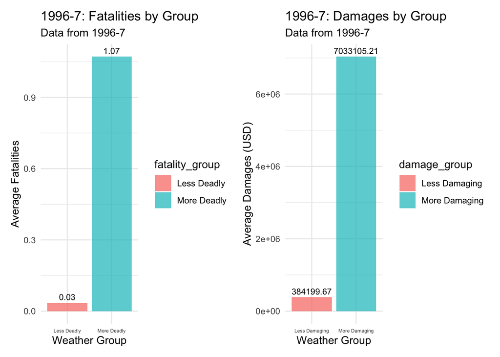

### Labeled graph for the 2022-3 period:

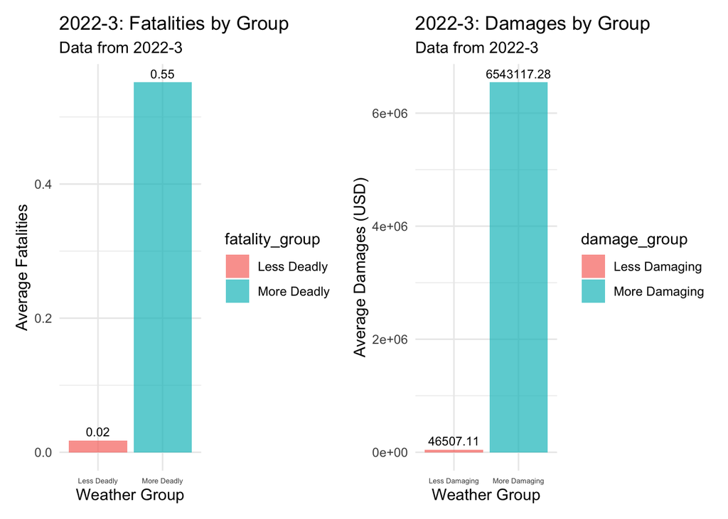

Below are tibbles showing event types, classifications, and impact averages for the entire dataset, 1996–7, and 2022–3. This frames changes and verifies classifications.

```
## # A tibble: 54 × 5
##    event_type            fatality_group damage_group  avg_fatalities_by_type
##    <chr>                 <chr>          <chr>                          <dbl>
##  1 Astronomical Low Tide Less Deadly    Less Damaging                0.00325
##  2 Blizzard              Less Deadly    Less Damaging                0.0183
##  3 Coastal Flood         Less Deadly    Less Damaging                0.0200
##  4 Cold/Wind Chill       Less Deadly    Less Damaging                0.0658
##  5 Debris Flow           Less Deadly    Less Damaging                0.0535
##  6 Dense Fog             Less Deadly    Less Damaging                0.0179
##  7 Dense Smoke           Less Deadly    Less Damaging                0.0140
##  8 Drought               Less Deadly    Less Damaging                0
##  9 Dust Devil            Less Deadly    Less Damaging                0.0137
## 10 Dust Storm            Less Deadly    Less Damaging                0.0459
## # ℹ 44 more rows
## # ℹ 1 more variable: avg_damage_by_type <dbl>
```

```
## # A tibble: 25 × 5
##    event_type      fatality_group damage_group  avg_fatalities_by_type
##    <chr>           <chr>          <chr>                          <dbl>
##  1 Blizzard        Less Deadly    Less Damaging                 0.0294
##  2 Cold/Wind Chill Less Deadly    Less Damaging                 0.0893
##  3 Dense Fog       Less Deadly    Less Damaging                 0
##  4 Flash Flood     Less Deadly    Less Damaging                 0.0712
##  5 Funnel Cloud    Less Deadly    Less Damaging                 0
##  6 Hail            Less Deadly    Less Damaging                 0
##  7 Heat            Less Deadly    Less Damaging                 0.0930
##  8 Heavy Rain      Less Deadly    Less Damaging                 0.0476
##  9 Heavy Snow      Less Deadly    Less Damaging                 0.0417
## 10 High Wind       Less Deadly    Less Damaging                 0.0208
## # ℹ 15 more rows
## # ℹ 1 more variable: avg_damage_by_type <dbl>
```

```
## # A tibble: 54 × 5
##    event_type            fatality_group damage_group  avg_fatalities_by_type
##    <chr>                 <chr>          <chr>                          <dbl>
##  1 Astronomical Low Tide Less Deadly    Less Damaging                0
##  2 Blizzard              Less Deadly    Less Damaging                0.0657
##  3 Coastal Flood         Less Deadly    Less Damaging                0.00289
##  4 Cold/Wind Chill       Less Deadly    Less Damaging                0.0499
##  5 Debris Flow           Less Deadly    Less Damaging                0.0262
##  6 Dense Fog             Less Deadly    Less Damaging                0.0488
##  7 Dense Smoke           Less Deadly    Less Damaging                0
##  8 Drought               Less Deadly    Less Damaging                0
##  9 Dust Devil            Less Deadly    Less Damaging                0
## 10 Dust Storm            Less Deadly    Less Damaging                0.0425
## # ℹ 44 more rows
## # ℹ 1 more variable: avg_damage_by_type <dbl>
```

## Changes

All averaged values decreased from 1996–7 to 2022–3. First, by creating and joining the year groups, we produced a tibble showing the percent and absolute change for each event type. Next, we calculated percent and absolute changes for the global averages of each period. Finally, we generated a simple percent change for each more/less category.

```r
# Create year groups
details_grouped_1996_7 <- details_grouped_1996_7 %>%
  mutate(year_group = "1996-1997")

details_grouped_2022_3 <- details_grouped_2022_3 %>%
  mutate(year_group = "2022-2023")

# Combine the data-sets
combined_data <- full_join(
  details_grouped_1996_7,
  details_grouped_2022_3,
  by = "event_type",
  suffix = c("_1996_7", "_2022_3")
)

# Calculate differences and percentage changes
combined_data <- combined_data %>%
  mutate(
    change_fatalities = avg_fatalities_by_type_2022_3 - avg_fatalities_by_type_1996_7,
    change_damage = avg_damage_by_type_2022_3 - avg_damage_by_type_1996_7,
    percent_change_fatalities = (change_fatalities / avg_fatalities_by_type_1996_7) * 100,
    percent_change_damage = (change_damage / avg_damage_by_type_1996_7) * 100
  )

# View
combined_data %>%
  select(event_type, change_fatalities, percent_change_fatalities, change_damage, percent_change_damage)
```

```
## # A tibble: 54 × 5
##    event_type      change_fatalities percent_change_fatalities change_damage
##    <chr>                       <dbl>                     <dbl>         <dbl>
##  1 Blizzard                 0.0363                       123.       -4.66e+5
##  2 Cold/Wind Chill         -0.0394                       -44.1      -3.97e+5
##  3 Dense Fog                0.0488                       Inf         5.69e+3
##  4 Drought                  0                            NaN        -7.52e+6
##  5 Flash Flood             -0.0544                       -76.5      -1.49e+5
##  6 Flood                   -0.00498                      -28.9      -2.35e+6
##  7 Frost/Freeze             0                            NaN        -4.71e+6
##  8 Funnel Cloud             0                            NaN         0
##  9 Hail                     0.000240                     Inf        -5.38e+4
## 10 Heat                     0.0244                        26.2       2.38e-3
## # ℹ 44 more rows
## # ℹ 1 more variable: percent_change_damage <dbl>
```

```r
# Compare the global averages between the two groups
comparison <- tibble(
  metric = c("Fatalities", "Damages"),
  avg_1996_7 = c(global_averages_1996_7$global_avg_fatalities, global_averages_1996_7$global_avg_damage),
  avg_2022_3 = c(global_averages_2022_3$global_avg_fatalities, global_averages_2022_3$global_avg_damage),
  absolute_change = avg_2022_3 - avg_1996_7,
  percent_change = (absolute_change / avg_1996_7) * 100
)

# View
comparison
```

```
## # A tibble: 2 × 5
##   metric      avg_1996_7 avg_2022_3 absolute_change percent_change
##   <chr>            <dbl>      <dbl>           <dbl>          <dbl>
## 1 Fatalities       0.117      0.116        -0.00121          -1.03
## 2 Damages    1713981.    768353.      -945628.              -55.2
```

```r
# Final category changes calculations
Percent_change_less_fatalities <- ((.02-.03)/.03)*100
Percent_change_more_fatalities <- ((.55-1.07)/1.07)*100
Percent_change_less_damages <- ((46507.11-384199.67)/384199.67)*100
Percent_change_more_damages <- ((6543117.28-7033105.21)/7033105.21)*100

# Laying it all out
Percent_change_less_fatalities
```

```
## [1] -33.33333
```

```r
Percent_change_more_fatalities
```

```
## [1] -48.59813
```

```r
Percent_change_less_damages
```

```
## [1] -87.89507
```

```r
Percent_change_more_damages
```

```
## [1] -6.966879
```

# Findings

While total damages and fatalities rose, average impact per event declined. This suggests that increased storm frequency has affected people and property more than storm strength.  
However, a limitation of this dataset is the inability to fully assess storm severity without accounting for infrastructure strength, which was unavailable.